# Using R to calculate standard biodiversity indices

For your homework, you will run code to calculate diversity indices for 15 forest plots in NNY (3 plots in each of 5 forests). You will also make a plot comparing diversity and will answer questions about the data. The data you are using were collected by students in Forest Ecology, Fall 2021.

Let’s begin by setting up our workspace, which involves a few lines of code that clean the environment and turn on some packages.

```r
rm(list = ls() ) #fill in the code to clear R's memory for a fresh start
library(tidyverse) #turns on a bunch of helpful packages
library(here) #turns on the here package for navigating directories
library(vegan) #turns on package for calculating diversity indices
library(betapart) #turns on package for beta diversity (needed for Jaccard)
library(rstatix) #turns on package with some matrix maniuplation functions
```

Now let’s pull in some data

```r
DF<-read.csv(here("Data","TreeSpecies2021.csv"))
```

DF has the number of trees of each species found in 15 forest plots (3 each from 5 different forests) in northern New York collected by students in Forest Ecology.

Each row is a forest plot. The column “ID” just gives a unique number to each of the fifteen plots. We sampled 3 plots in each of 5 forests. The forest is identified in the second column and the plot number in that forest in the third column. The remaining columns all identify the abundance of trees > 10 cm diameter by species.

Let’s set aside the first three columns into a new dataframe for later use:

```r
DivIndices<-DF[, 1:3  ] #fill in the brackets to grab the 1st 3 columns
```

And make a dataframe that just has the tree species Now combine those two into a third column to get unique plot IDS

```r
Trees<-DF[,4:24  ] #fill in the brackets to grab just the columns of tree species data but not sites
```

Now add a column to the DivIndices to identify plot and forest

```r
DivIndices$Forest_Plot<-paste(DivIndices$Forest, "-", DivIndices$Plot)
```

Now use the `vegan` package to calculate diversity indices.Save the results of each index as a new column in DivIndices

```r
#species richness
DivIndices$SR<-specnumber(Trees) #fill in the brackets to specify the correct columns

#simpson's index
DivIndices$Simpson<-diversity(Trees, index = "simpson") #fill in the brackets to specify the correct columns

DivIndices$InvSimpson<-diversity(Trees, index = "invsimpson") #fill in the brackets to specify the correct columns

#shanon index
DivIndices$Shannon<-diversity(Trees, index = "shannon")  #fill in the brackets to specify the correct columns
View(DivIndices)
```

Now let’s go from wide to long format for DivIndices

```r
DivLong <- DivIndices %>% pivot_longer(cols = SR:Shannon, values_to = "Value")
```

Now let’s calculate some summary statistics

```r
TreeSum<-DivLong %>% group_by(name, Forest) %>% summarise(
    IndexN = length(Value),
    IndexAvg = mean(Value, na.rm = T),
    IndexSD = sd(Value, na.rm = T),
    IndexSEM = IndexSD/sqrt(IndexN),
    IndexMax = max(Value),
    IndexMin = min(Value),
    Quant10 = quantile(Value, probs = c(0.10)),
    Quant90 = quantile(Value, probs = c(0.90))
)
```

Now join data

```r
AllData<-full_join(DivLong, TreeSum, by = c("name", "Forest"))
```

Now let’s make a plot

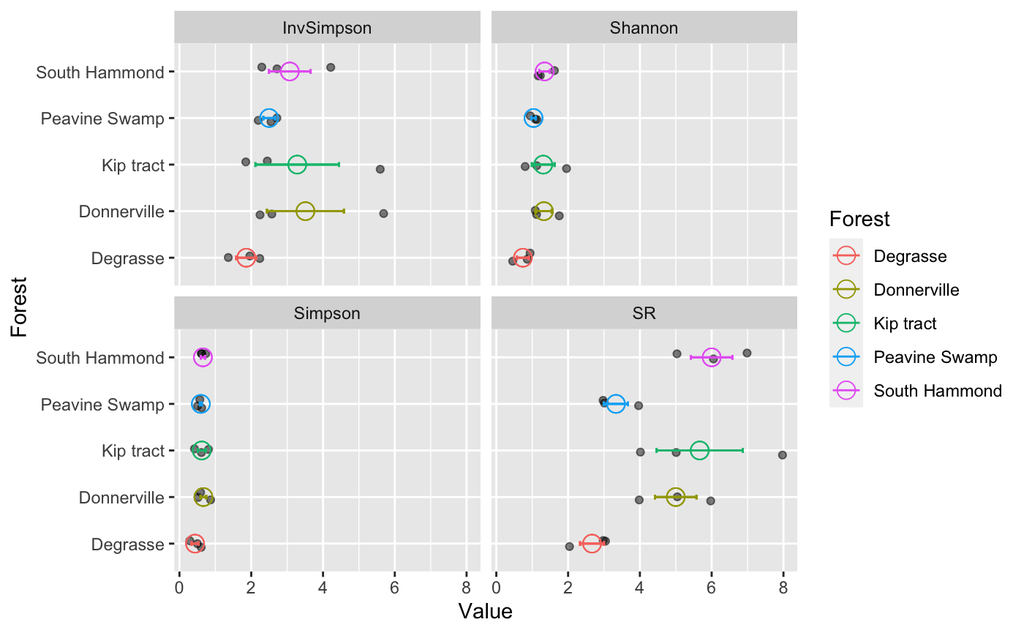

```r
ggplot(AllData, aes(Forest, Value))+
  geom_jitter(alpha = 0.5,  width = 0.1, height = 0.05)+
  geom_point(aes(Forest, IndexAvg, color = Forest), shape = 21, size = 4)+
  geom_errorbar(aes(Forest,ymin = IndexAvg-IndexSEM, ymax = IndexAvg+IndexSEM, color = Forest), width = 0.1)+
  facet_wrap(~name)+
  coord_flip()
```

```r
NA
```

Save the plot

```r
ggsave(here("Data", "Outputs", "TreeDiversity.png"), width = 6, height = 4)
```

Now calculate the Jaccard index for all pairs of plots

```r
#jaccard index
Jaccard<-betadiver(Trees, "j") #j indicates to use the a/a+b+c formula
#result is of class 'distance' - convert to a matrix
Jaccard<-as.matrix(Jaccard)
Jaccard <- round(Jaccard, digits = 3)
```

Now use `betapart`package to get shared species between sites. The function requires a set of presence/absence rather than abundance data so we have to convert our DF dataset to that.

```r
#requires a dataset of presence/absence data so make that first
PresAb<-Trees

PresAb[][PresAb[] != 0]<- 1 #assigns all values > 0 in cols 3:23 to 1
```

Now we can run the function to get the number of shared species between each pair of plots.

```r
Beta<-betapart.core(PresAb)#result is a list; we just need the one part of the list called Shared.
Shared<-Beta$shared
```

Now it would be ideal if we could create a matrix with number of shared species (“a”) above the diagonal , species richness of each plot along the diagonal, and Jaccard index below the diagonal.

Let’s start by adding row and column names to our existing matrices to keep track of things.

```r
row.names(Jaccard)<-DivIndices$Forest_Plot
colnames(Jaccard)<-DivIndices$Forest_Plot

row.names(Shared)<-DivIndices$Forest_Plot
colnames(Shared)<-DivIndices$Forest_Plot
```

Since we want the # of shared species above the diagonal, let’s start with the shared matrix. Conveniently, it also has the number of species per plot as its diagonal.

So all we really need to do is put the Jaccard data below the diagonal.

```r
#using base r
Shared[lower.tri(Shared)]<-Jaccard[lower.tri(Jaccard, diag = FALSE)]
Shared<- round(Shared, digits = 2)
View(Shared)
```

Now write the matrix to a new location

```r
write.csv(Shared, here("Data", "Outputs","ForestDivComparison.csv"))
```

And write the diversity output to a new location

```r
write.csv(AllData, here("Data", "Outputs", "ForestDiversity.csv"))
```